# Simulation

Statistical Computing, 36-350

Thursday July 19, 2018

# Last time: Functions

- Function: formal encapsulation of a block of code; generally makes your code easier to understand, to work with, and to modify
- Functions are absolutely critical for writing (good) code for medium or large projects
- A function’s structure consists of three main parts: inputs, body, and output
- R allows the function designer to specify default values for any of the inputs
- R doesn’t allow the designer to return multiple outputs, but can return a list
- Side effects are things that happen as a result of a function call, but that aren’t returned as an output
- Top-down design means breaking a big task into small parts, implementing each of these parts, and then putting them together

# Part I

*Simulation basics*

# Why simulate?

R gives us unique access to great simulation tools (unique compared to other languages). Why simulate? Welcome to the 21st century! Two reasons:

- Often, simulations can be easier than hand calculations
- Often, simulations can be made more realistic than hand calculations

# Sampling from a given vector

To sample from a given vector, use `sample()`

```r
sample(x=letters, size=10) # Without replacement, the default
```

```
##  [1] "b" "c" "j" "d" "g" "e" "f" "w" "i" "n"
```

```r
sample(x=c(0,1), size=10, replace=TRUE) # With replacement
```

```
##  [1] 0 1 1 0 0 0 0 0 0 0
```

```r
sample(x=10) # Arguments set as x=1:10, size=10, replace=FALSE
```

```
##  [1]  3  2  8 10  4  6  1  5  7  9
```

# Random number generation

To sample from a normal distribution, we have the utility functions:

- `rnorm()`: generate normal random variables
- `pnorm()`: normal distribution function, $\Phi(x)=P(Z \leq x)$
- `dnorm()`: normal density function, $\phi(x)= \Phi'(x)$
- `qnorm()`: normal quantile function, $q(y)=\Phi^{-1}(y)$, i.e., $\Phi(q(y))=y$

Replace “norm” with the name of another distribution, all the same functions apply. E.g., “t”, “exp”, “gamma”, “chisq”, “binom”, “pois”, etc.

# Random number examples

Standard normal random variables (mean 0 and variance 1)

```r
n = 1000
z = rnorm(n, mean=0, sd=1) # These are the defaults for mean, sd
mean(z)  # Check: sample mean is approximately 0
```

```
## [1] -0.02432108
```

```r
var(z)   # Check: sample variance is approximately 1
```

```
## [1] 1.10069
```

# Estimated distribution function

To compute empirical cumulative distribution function (ECDF)—the standard estimator of the cumulative distribution function—use `ecdf()`

```r
x = seq(-3,3,length=100)
ecdf.fun = ecdf(z) # Create the ECDF
class(ecdf.fun) # It's a function!
```

```
## [1] "ecdf"     "stepfun"  "function"
```

```r
ecdf.fun(0)
```

```
## [1] 0.519
```

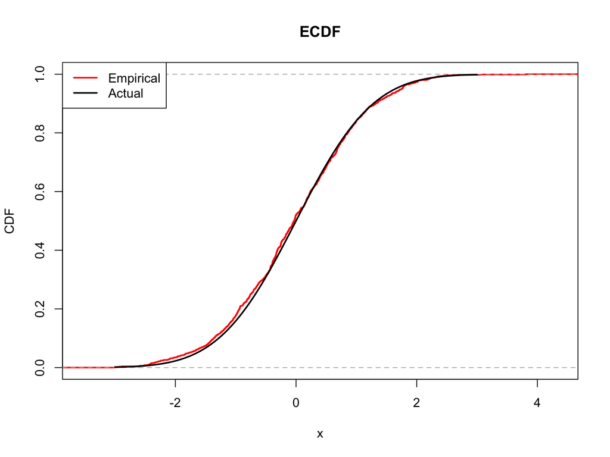

```r
# We can plot it
plot(ecdf.fun, lwd=2, col="red", ylab="CDF", main="ECDF")
lines(x, pnorm(x), lwd=2)
legend("topleft", legend=c("Empirical", "Actual"), lwd=2,
       col=c("red","black"))
```

# Estimated density function

To compute histogram—a basic estimator of the density based on binning—use `hist()`

```r
hist.obj = hist(z, breaks=30, plot=FALSE)
class(hist.obj) # It's a list
```

```
## [1] "histogram"
```

```r
hist.obj$breaks # These are the break points that were used
```

```
##  [1] -3.2 -3.0 -2.8 -2.6 -2.4 -2.2 -2.0 -1.8 -1.6 -1.4 -1.2 -1.0 -0.8 -0.6
## [15] -0.4 -0.2  0.0  0.2  0.4  0.6  0.8  1.0  1.2  1.4  1.6  1.8  2.0  2.2
## [29]  2.4  2.6  2.8  3.0  3.2  3.4  3.6  3.8  4.0
```

```r
hist.obj$density # These are the estimated probabilities
```

```
##  [1] 0.005 0.015 0.000 0.055 0.050 0.050 0.065 0.090 0.135 0.170 0.250
## [12] 0.280 0.295 0.295 0.430 0.410 0.310 0.350 0.335 0.320 0.295 0.225
## [23] 0.135 0.110 0.125 0.065 0.050 0.050 0.015 0.010 0.000 0.005 0.000
## [34] 0.000 0.000 0.005
```

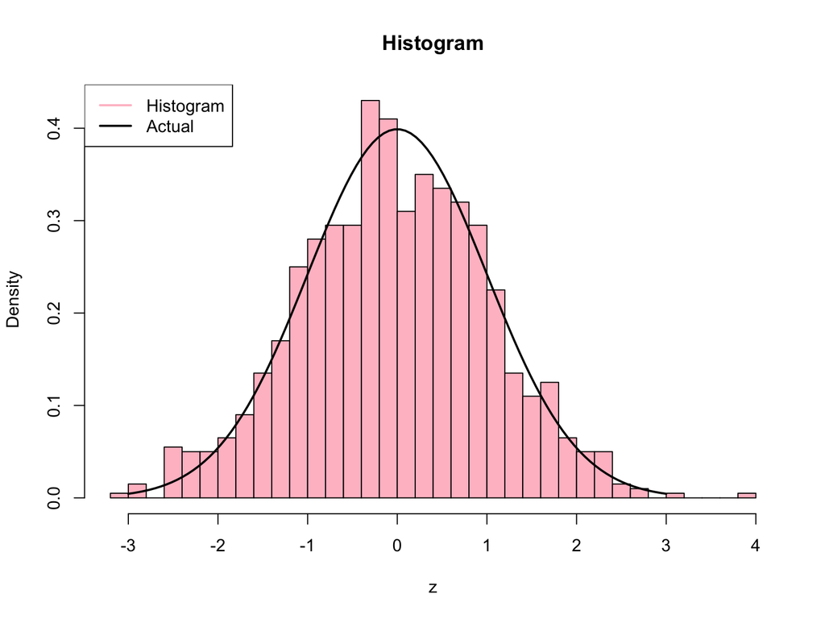

```r
# We can plot it
plot(hist.obj, col="pink", freq=FALSE, main="Histogram")
lines(x, dnorm(x), lwd=2)
legend("topleft", legend=c("Histogram", "Actual"), lwd=2,
       col=c("pink","black"))
```

# Tangent on estimation (did you know?)

Interesting statistical facts:

- When you have lots of data, the empirical distribution function will always be close to the actual distribution function (Glivenko-Cantelli, “Fundamental Theorem of Statistics”)
- When you have lots of data, the histogram estimator is not always close to the density function, only when the underlying density is quite smooth
- In general, density estimation is tricky, there are many estimators beyond histograms worth studying/knowing about; e.g., `density()` uses a kernel density estimator

# Part II

*Pseudorandomness and seeds*

# Same function call, different results

Not surprisingly, we get different draws each time we call `rnorm()`

```r
mean(rnorm(n))
```

```
## [1] -0.02218593
```

```r
mean(rnorm(n))
```

```
## [1] 0.05192108
```

```r
mean(rnorm(n))
```

```
## [1] -0.01841491
```

```r
mean(rnorm(n))
```

```
## [1] -0.0363976
```

# Is it really random?

Random numbers generated in R (in any language) are not “truly” random; they are what we call **pseudorandom**

- These are numbers generated by computer algorithms that very closely mimick “truly” random numbers
- The study of such algorithms is an interesting research area in its own right!
- The default algorithm in R (and in nearly all software languages) is called the “Mersenne Twister”
- Type `?Random` in your R console to read more about this (and to read how to change the algorithm used for pseudorandom number generation, which you should never really have to do, by the way)

# Setting the random seed

All pseudorandom number generators depend on what is called a **seed** value

- This puts the random number generator in a well-defined “state”, so that the numbers it generates, from then on, will be reproducible
- The seed is just an integer, and can be set with `set.seed()`
- The reason we set it: so that when someone else runs our simulation code, they can see the same—albeit, still random—results that we do

# Seed examples

```r
# Getting the same 5 random normals over and over
set.seed(0); rnorm(5)
```

```
## [1]  1.2629543 -0.3262334  1.3297993  1.2724293  0.4146414
```

```r
set.seed(0); rnorm(5)
```

```
## [1]  1.2629543 -0.3262334  1.3297993  1.2724293  0.4146414
```

```r
set.seed(0); rnorm(5)
```

```
## [1]  1.2629543 -0.3262334  1.3297993  1.2724293  0.4146414
```

```r
# Different seeds, different numbers
set.seed(1); rnorm(5)
```

```
## [1] -0.6264538  0.1836433 -0.8356286  1.5952808  0.3295078
```

```r
set.seed(2); rnorm(5)
```

```
## [1] -0.89691455  0.18484918  1.58784533 -1.13037567 -0.08025176
```

```r
set.seed(3); rnorm(5)
```

```
## [1] -0.9619334 -0.2925257  0.2587882 -1.1521319  0.1957828
```

```r
# Each time the seed is set, the same sequence follows (indefinitely)
set.seed(0); rnorm(3); rnorm(2); rnorm(1)
```

```
## [1]  1.2629543 -0.3262334  1.3297993
```

```
## [1] 1.2724293 0.4146414
```

```
## [1] -1.53995
```

```r
set.seed(0); rnorm(3); rnorm(2); rnorm(1)
```

```
## [1]  1.2629543 -0.3262334  1.3297993
```

```
## [1] 1.2724293 0.4146414
```

```
## [1] -1.53995
```

```r
set.seed(0); rnorm(3); rnorm(2); rnorm(1)
```

```
## [1]  1.2629543 -0.3262334  1.3297993
```

```
## [1] 1.2724293 0.4146414
```

```
## [1] -1.53995
```

# Part III

*Iteration and simulation*

# Drug effect model

- Let’s start with a motivating example: suppose we had a model for the way a drug affected certain patients
- All patients will undergo chemotherapy. We believe those who aren’t given the drug experience a reduction in tumor size of percentage
  $$X_{\mathrm{no\,drug}} \sim 100 \cdot \mathrm{Exp}(\mathrm{mean}=R),
  \;\;\; R \sim \mathrm{Unif}(0,1)$$
- And those who were given the drug experience a reduction in tumor size of percentage
  $$X_{\mathrm{drug}} \sim 100 \cdot \mathrm{Exp}(\mathrm{mean}=2)$$
  (Here $\mathrm{Exp}$ denotes the exponential distribution, and $\mathrm{Unif}$ the uniform distribution)

# What would you do?

What would you do if you had such a model, and your scientist collaborators asked you: *how many patients would we need to have in each group (drug, no drug), in order to reliably see that the average reduction in tumor size is large?*

- Answer used to be: get out your pen and paper, make some approximations
- Answer is now: simulate from the model, no approximations required!

# So, let’s simulate!

```r
# Simulate, supposing 60 subjects in each group
set.seed(0)
n = 60
mu.drug = 2
mu.nodrug = runif(n, min=0, max=1)
x.drug = 100*rexp(n, rate=1/mu.drug)
x.nodrug = 100*rexp(n, rate=1/mu.nodrug)
```

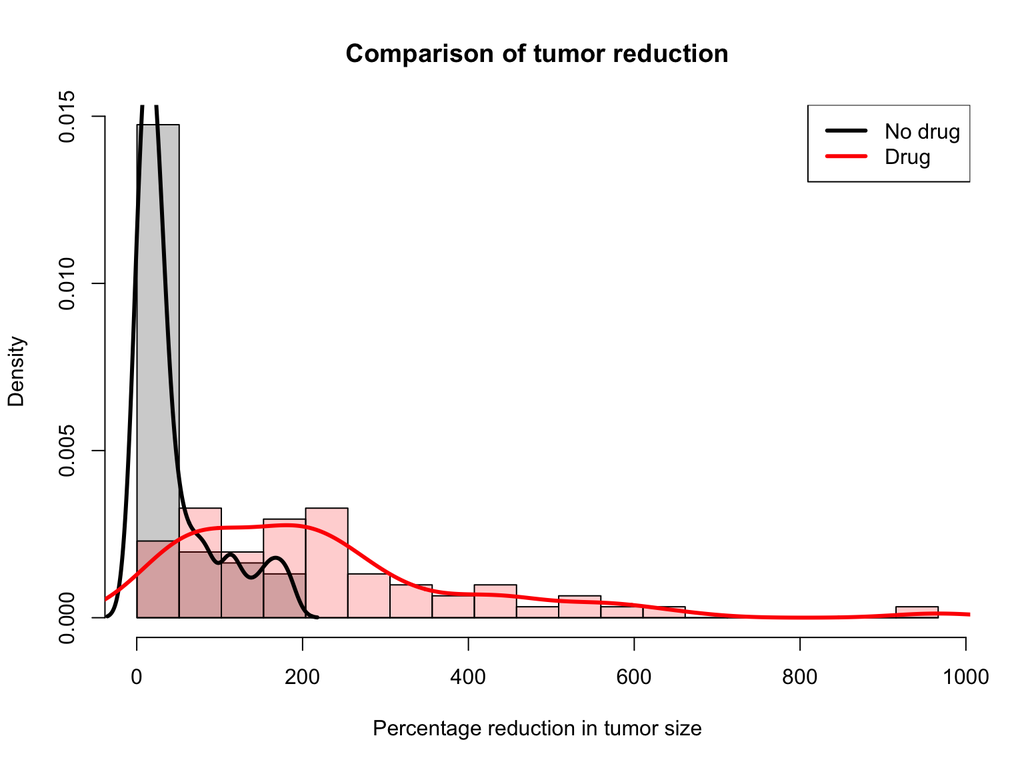

```r
# Find the range of all the measurements together, and define breaks
x.range = range(c(x.nodrug,x.drug))
breaks = seq(min(x.range),max(x.range),length=20)

# Produce hist of the non drug measurements, then drug measurements on top
hist(x.nodrug, breaks=breaks, probability=TRUE, xlim=x.range,
     col="lightgray", xlab="Percentage reduction in tumor size",
     main="Comparison of tumor reduction")

# Plot a histogram of the drug measurements, on top
hist(x.drug, breaks=breaks, probability=TRUE, col=rgb(1,0,0,0.2), add=TRUE)

# Draw estimated densities on top, for each dist
lines(density(x.nodrug), lwd=3, col=1)
lines(density(x.drug), lwd=3, col=2)
legend("topright", legend=c("No drug","Drug"), lty=1, lwd=3, col=1:2)
```

# Repetition and reproducibility

- One single simulation is not always trustworthy (depends on the situation, of course)
- In general, simulations should be repeated and aggregate results reported—requires iteration!
- To make random number draws reproducible, we must set the seed with `set.seed()`
- More than this, to make simulation results reproducible, we need to follow **good programming practices**
- Gold standard: any time you show a simulation result (a figure, a table, etc.), you have code that can be run (by anyone) to produce exactly the same result

# Iteration and simulation (and functions): good friends

- Writing a **function** to complete a single run of your simulation is often very helpful
- This allows the simulation itself to be intricate (e.g., intricate steps, several simulation parameters), but makes running the simulation simple
- Then you can use **iteration** to run your simulation over and over again
- Good design practice: write another function for this last part (running your simulation many times)

# Code sketch

Consider the code below for a generic simulation. Think about how you would frame this for the drug effect example, which you’ll revisit in lab

```
# Function to do one simulation run
one.sim = function(param1, param2=value2, param3=value3) {
  # Possibly intricate simulation code goes here
}

# Function to do repeated simulation runs
rep.sim = function(nreps, param1, param2=value2, param3=value3, seed=NULL) {
  # Set the seed, if we need to
  if(!is.null(seed)) set.seed(seed)

  # Run the simulation over and over
  sim.objs = vector(length=nreps, mode="list")
  for (r in 1:nreps) {
    sim.objs[r] = one.sim(param1, param2, param3)
  }

  # Aggregate the results somehow, and then return something
}
```

# Saving results

Sometimes simulations take a long time to run, and we want to save intermediate or final output, for quick reference later

There two different ways of saving things from R (there are more than two, but here are two useful ones):

- `saveRDS()`: allows us to save single R objects (like a vector, matrix, list, etc.), in (say) .rds format. E.g.,

  ```r
  saveRDS(my.mat, file="my.matrix.rds")
  ```

- `save()`: allows us to save any number of R objects in (say) .rdata format. E.g.,

  ```r
  save(mat.x, mat.y, list.z, file="my.objects.rdata")
  ```

Note: there is a big difference between how these two treat variable names

# Loading results

Corresponding to the two different ways of saving, we have two ways of loading things into R:

- `readRDS()`: allows us to load an object that has been saved by `savedRDS()`, and **assign a new variable name**. E.g.,

  ```r
  my.new.mat = readRDS("my.matrix.rds")
  ```

- `load()`: allows us to load all objects that have been saved through `save()`, **according to their original variables names**. E.g.,

  ```r
  load("my.objects.rdata")
  ```

# Part IV

*Reading in and writing out data*

# Reading in data from the outside

All along, we’ve already been reading in data from the outside, using:

- `readLines()`: reading in lines of text from a file or webpage; returns vector of strings
- `read.table()`: read in a data table from a file or webpage; returns data frame
- `read.csv()`: like the above, but assumes comma separated data; returns data frame

This week we’ll focus on `read.table()`, `read.csv()` and their counterparts `write.table()`, `write.csv()`, respectively

# Reading in data from a previous R session

Reminder that we’ve already learned two ways to read/write in data in specialized R formats:

- `readRDS()`, `saveRDS()`: functions for reading/writing single R objects from/to a file
- `load()`, `save()`: functions for reading/writing any number of R objects from/to a file

Advantage: these can be a lot more memory efficient than what we’ll cover this week. Disadvantage: they’re limited in scope in the sense that they can only communicate with R

# `read.table()`, `read.csv()`

Have a table full of data, just not in the R file format? Then `read.table()` is the function for you. It works as in:

- `read.table(file=file.name, sep=" ")`, to read data from a local file on your computer called `file.name`, assuming (say) space separated data
- `read.table(file=webpage.link, sep="\t")`, to read data from a webpage up at `webpage.link`, assuming (say) tab separated data

The function `read.csv()` is just a shortcut for using `read.table()` with `sep=","`. (But note: these two actually differ on some of the default inputs!)

# Helpful input arguments

- `header`: boolean, TRUE is the first line should be interpreted as column names
- `sep`: string, specifies what separates the entries; empty string “” is interpreted to mean any white space
- `quote`: string, specifies what set of characters signify the beginning and end of quotes; empty string “” disables quotes altogether

Other helpful inputs: `skip`, `row.names`, `col.names`. You can read about them in the help file for `read.table()`

# Example of reading in data

```r
sprint.df = read.table(
  file="https://raw.githubusercontent.com/linnylin92/36-350_public/master/dat/sprint.m.dat",
  sep="\t", header=TRUE, quote="")
head(sprint.df)
```

```
##   Rank Time Wind        Name Country Birthdate     City       Date
## 1    1 9.58  0,9  Usain Bolt     JAM  21.08.86   Berlin 16.08.2009
## 2    2 9.63  1,5  Usain Bolt     JAM  21.08.86   London 05.08.2012
## 3    3 9.69  0,0  Usain Bolt     JAM  21.08.86  Beijing 16.08.2008
## 4    3 9.69  2,0   Tyson Gay     USA  09.08.82 Shanghai 20.09.2009
## 5    3 9.69 -0,1 Yohan Blake     JAM  26.12.89 Lausanne 23.08.2012
## 6    6 9.71  0,9   Tyson Gay     USA  09.08.82   Berlin 16.08.2009
```

```r
sapply(sprint.df, class)
```

```
##        Rank        Time        Wind        Name     Country   Birthdate
##   "integer"   "numeric" "character" "character" "character" "character"
##        City        Date
## "character" "character"
```

# `write.table()`, `write.csv()`

To write a data frame (or matrix) to a text file, use `write.table()` or `write.csv()`. These are the counterparts to `read.table()` and `read.csv()`, and they work as in:

- `write.table(my.df, file="my.df.txt", sep=" ", quote=FALSE)`, to write `my.dat` to the text file “my.df.txt” (to be created in your working directory), with (say) space separation, and no quotes around the entries
- `write.csv(my.df, file="my.df.csv", quote=FALSE)`, to write `my.dat` to the text file “my.df.csv” (to be created in your working directory), with comma separation, and no quotes

Note that `quote=FALSE`, signifying that no quotes should be put around the printed data entries, seems always preferable (default is `quote=TRUE`). Also, setting `row.names=FALSE` and `col.names=FALSE` will disable the printing of row and column names (defaults are `row.names=TRUE` and `col.names=TRUE`)

# Reordering data

Sometimes it’s convenient to reorder our data, say the rows of our data frame (or matrix). Recall:

- The function `order()` takes in a vector, and returns the vector of indices that put this vector in increasing order
- Set the input `decreasing=TRUE` in `order()` to get decreasing order
- We can apply compute an appropriate vector of indices, and then use this on rows of our data frame to reorder all of the columns simultaneously

# Examples of reordering

```r
# The sprint data has its rows ordered by the fastest 100m time to the slowest.
# Suppose we wanted to reorder, from slowest to fastest
i.slow = order(sprint.df$Time, decreasing=TRUE) # By decreasing sprint time
sprint.df.slow = sprint.df[i.slow,] # Reorder rows by decreasing sprint time
head(sprint.df.slow)
```

```
##      Rank  Time Wind         Name Country Birthdate             City
## 2523 2532 10.09  1,8  Mel Lattany     USA  10.08.59 Colorado Springs
## 2524 2532 10.09 -0,9  Mel Lattany     USA  10.08.59      Z&uuml;rich
## 2525 2532 10.09  1,3   Carl Lewis     USA  01.07.61           Walnut
## 2526 2532 10.09  0,6 Calvin Smith     USA  08.01.61           Athens
## 2527 2532 10.09 -1,7   Carl Lewis     USA  01.07.61     Indianapolis
## 2528 2532 10.09 -0,9 Calvin Smith     USA  08.01.61      Z&uuml;rich
##            Date
## 2523 30.07.1978
## 2524 19.08.1981
## 2525 25.04.1982
## 2526 14.05.1982
## 2527 02.07.1982
## 2528 18.08.1982
```

```r
# Suppose we wanted to reorder the rows by sprinter name, alphabetically
i.name = order(sprint.df$Name) # By sprinter name
sprint.df.name = sprint.df[i.name,] # Reorder rows by name
head(sprint.df.name)
```

```
##      Rank  Time Wind            Name Country Birthdate          City
## 1294 1202 10.03  0,5 Aaron Armstrong     TTO  14.10.77 Port of Spain
## 1462 1366 10.04  1,0 Aaron Armstrong     TTO  14.10.77 Port of Spain
## 2191 2011 10.07  1,0 Aaron Armstrong     TTO  14.10.77 Port of Spain
## 550   473  9.96  2,0     Aaron Brown     CAN  27.05.92     Montverde
## 1057  954 10.01  1,8     Aaron Brown     CAN  27.05.92     Montverde
## 1733 1581 10.05  1,9     Aaron Brown     CAN  27.05.92        Eugene
##            Date
## 1294 20.06.2009
## 1462 25.06.2005
## 2191 13.08.2011
## 550  11.06.2016
## 1057 11.06.2016
## 1733 05.06.2013
```

# Part V

*Merging data*

# Merging data frames

Suppose you have two data frames `X`, `Y`, and you want to combine them

- Simplest case: the data frames have exactly the same number of rows, that the rows represent exactly the same units, and you want all columns from both; just use, `data.frame(X,Y)`
- Next best case: you know that the two data frames have the same rows, but you only want certain columns from each; just use, e.g., `data.frame(X$col1,X$col5,Y$col3)`
- Next best case: same number of rows but in different order; put one of them in same order as the other, with `order()`. Alternatively, use `merge()`
- Worse cases: different numbers of rows … hard to line up rows …

# Example: big city drivers

People in larger cities (larger areas) drive more—seems like a reasonable hypothesis, but is it true?

Distance driven, and city population, from http://www.fhwa.dot.gov/policyinformation/statistics/2011/hm71.cfm:

```r
fha = read.csv(
  file="https://raw.githubusercontent.com/linnylin92/36-350_public/master/dat/fha.csv",
  colClasses=c("character","double","double","double"), na.strings="NA")
nrow(fha)
```

```
## [1] 498
```

```r
head(fha)
```

```
##                                   City Population Miles.of.Road
## 1         New York--Newark, NY--NJ--CT   18351295         43893
## 2 Los Angeles--Long Beach--Anaheim, CA   12150996         24877
## 3                      Chicago, IL--IN    8608208         25905
## 4                            Miami, FL    5502379         15641
## 5         Philadelphia, PA--NJ--DE--MD    5441567         19867
## 6    Dallas--Fort Worth--Arlington, TX    5121892         21610
##   Daily.Miles.Traveled
## 1               286101
## 2               270807
## 3               172708
## 4               125899
## 5                99190
## 6               125389
```

Area and population of “urbanized areas”, from http://www2.census.gov/geo/ua/ua_list_all.txt:

```r
ua = read.csv(file="https://raw.githubusercontent.com/linnylin92/36-350_public/master/dat/ua.dat",
              sep=";")
nrow(ua)
```

```
## [1] 3598
```

```r
head(ua)
```

```
##   UACE           NAME   POP    HU AREALAND AREALANDSQMI AREAWATER
## 1   37  Abbeville, LA 19824  8460 29222871        11.28    300497
## 2   64  Abbeville, SC  5243  2578 11315197         4.37     19786
## 3   91 Abbotsford, WI  3966  1616  5363441         2.07     13221
## 4  118   Aberdeen, MS  4666  2050  7416616         2.86     52732
## 5  145   Aberdeen, SD 25977 12114 33002447        12.74    247597
## 6  172   Aberdeen, WA 29856 13139 39997951        15.44   1929689
##   AREAWATERSQMI POPDEN LSADC
## 1          0.12 1757.0    76
## 2          0.01 1200.1    76
## 3          0.01 1915.2    76
## 4          0.02 1629.4    76
## 5          0.10 2038.6    76
## 6          0.75 1933.3    76
```

# Difficulties in navigating the merge

- $\approx 500$ cities versus $\approx 4000$ “urbanized areas”
- `fha` orders cities by population, `ua` is alphabetical by name
- Both have place names, but those don’t always agree
- Not even common names for the shared columns

# Lesson: find the unique identifier

But both use the same census figures for population! And it turns out every settlement (in the top 498) has a unique census population:

```r
length(unique(fha$Population)) == nrow(fha)
```

```
## [1] TRUE
```

```r
ua.pop.top498 = sort(ua$POP, decreasing=TRUE)[1:nrow(fha)]
max(abs(fha$Population - ua.pop.top498))
```

```
## [1] 0
```

# First way to merge

Reorder area column in second table by population, append to first table

```r
ind.pop = order(ua$POP, decreasing=TRUE) # Order by population
df1 = data.frame(fha, area=ua$AREALANDSQMI[ind.pop][1:nrow(fha)])
# Neaten up names
colnames(df1) = c("City","Population","Roads","Mileage","Area")
nrow(df1)
```

```
## [1] 498
```

```r
head(df1)
```

```
##                                   City Population Roads Mileage    Area
## 1         New York--Newark, NY--NJ--CT   18351295 43893  286101 3450.20
## 2 Los Angeles--Long Beach--Anaheim, CA   12150996 24877  270807 1736.02
## 3                      Chicago, IL--IN    8608208 25905  172708 2442.75
## 4                            Miami, FL    5502379 15641  125899 1238.61
## 5         Philadelphia, PA--NJ--DE--MD    5441567 19867   99190 1981.37
## 6    Dallas--Fort Worth--Arlington, TX    5121892 21610  125389 1779.13
```

# Second way to merge

Use the `merge()` function

```r
df2 = merge(x=fha, y=ua, by.x="Population", by.y="POP")
nrow(df2)
```

```
## [1] 498
```

```r
tail(df2, 3)
```

```
##     Population                                 City Miles.of.Road
## 496    8608208                      Chicago, IL--IN         25905
## 497   12150996 Los Angeles--Long Beach--Anaheim, CA         24877
## 498   18351295         New York--Newark, NY--NJ--CT         43893
##     Daily.Miles.Traveled  UACE                                 NAME
## 496               172708 16264                      Chicago, IL--IN
## 497               270807 51445 Los Angeles--Long Beach--Anaheim, CA
## 498               286101 63217         New York--Newark, NY--NJ--CT
##          HU   AREALAND AREALANDSQMI AREAWATER AREAWATERSQMI POPDEN LSADC
## 496 3459257 6326686332      2442.75 105649916         40.79 3524.0    75
## 497 4217448 4496266014      1736.02  61141327         23.61 6999.3    75
## 498 7263095 8935981360      3450.20 533176599        205.86 5318.9    75
```

# `merge()`

The `merge()` function tries to merge two data frames according to common columns, as in: `merge(x, y, by.x="SomeXCol", by.y="SomeYCol")`, to join two data frames `x`, `y`, by matching the columns “SomeXCol” and “SomeYCol”

- Default (no `by.x`, `by.y` specified) is to match all columns with common names
- Output will be a new data frame that has all the columns of both data frames
- If you know databases, then `merge()` is doing a JOIN (if you don’t know what that means, you will by the end of the semester!)

# Using `order()` and manual tricks versus `merge()`

- Reordering is easier to grasp; `merge()` takes some learning
- Reordering is simplest when there’s only one column to merge on; `merge()` handles many columns
- Reorderng is simplest when the data frames are the same size; `merge()` handles different sizes automatically

# So, do bigger cities mean more driving?

[figure not shown]

```r
# Convert 1,000s of miles to miles
df1$Mileage = 1000*df1$Mileage
# Plot daily miles per person vs. area
plot(x=df1$Area, y=df1$Mileage/df1$Population, log="x",
     xlab="Miles driven per person per day",
     ylab="City area in square miles")
# Impressively flat regression line
abline(lm(Mileage/Population ~ Area, data=df1), col="red")
```

# Summary

- Running simulations is an integral part of being a statistician in the 21st century
- R provides us with a utility functions for simulations from a wide variety of distributions
- To make your simulation results reproducible, you must set the seed, using `set.seed()`
- There is a natural connection between iteration, functions, and simulations
- Saving and loading results can be done in two formats: rds and rdata formats
- Read in data from a previous R session with `readRDS()`, `load()`
- Read in data from the outside with `read.table()`, `read.csv()`
- Can sometimes be tricky to get arguments right in `read.table()`, `read.csv()`; helps sometimes take a look at the original data files to see their structure
- For reordering data, use `order()`, `rev()`, and proper indexing
- For merging data, use `merge()`; but can do it manually using reordering tricks